# Week141p_part1

Mercy Cherotich

2/5/2022

# importing libraries

```r
library(caret)
library(superml)
```

```r
#install.packages("devtools", type = "win.binary")
remotes::install_github('vqv/ggbiplot')
library(ggbiplot)
#suppressWarnings(
        #suppressMessages(if
                         #(!require(corrplot, quietly=TRUE))
                #install.packages("corrplot")))
library(corrplot)
```

# Loading dataset

```r
#reading the data set
sales<- read.csv("C:\\Users\\MERCY\\Downloads\\Supermarket_Dataset_1 - Sales Data.csv")
```

**Previewing the data**

```r
#previewing the head
head(sales)
```

```
##    Invoice.ID Branch Customer.type Gender           Product.line Unit.price
## 1 750-67-8428      A        Member Female      Health and beauty      74.69
## 2 226-31-3081      C        Normal Female Electronic accessories      15.28
## 3 631-41-3108      A        Normal   Male     Home and lifestyle      46.33
## 4 123-19-1176      A        Member   Male      Health and beauty      58.22
## 5 373-73-7910      A        Normal   Male      Sports and travel      86.31
## 6 699-14-3026      C        Normal   Male Electronic accessories      85.39
##   Quantity     Tax      Date  Time     Payment   cogs gross.margin.percentage
## 1        7 26.1415  1/5/2019 13:08     Ewallet 522.83                4.761905
## 2        5  3.8200  3/8/2019 10:29        Cash  76.40                4.761905
## 3        7 16.2155  3/3/2019 13:23 Credit card 324.31                4.761905
## 4        8 23.2880 1/27/2019 20:33     Ewallet 465.76                4.761905
## 5        7 30.2085  2/8/2019 10:37     Ewallet 604.17                4.761905
## 6        7 29.8865 3/25/2019 18:30     Ewallet 597.73                4.761905
##   gross.income Rating    Total
## 1      26.1415    9.1 548.9715
## 2       3.8200    9.6  80.2200
## 3      16.2155    7.4 340.5255
## 4      23.2880    8.4 489.0480
## 5      30.2085    5.3 634.3785
## 6      29.8865    4.1 627.6165
```

```r
#previewing the tail
tail(sales)
```

```
##       Invoice.ID Branch Customer.type Gender           Product.line Unit.price
## 995  652-49-6720      C        Member Female Electronic accessories      60.95
## 996  233-67-5758      C        Normal   Male      Health and beauty      40.35
## 997  303-96-2227      B        Normal Female     Home and lifestyle      97.38
## 998  727-02-1313      A        Member   Male     Food and beverages      31.84
## 999  347-56-2442      A        Normal   Male     Home and lifestyle      65.82
## 1000 849-09-3807      A        Member Female    Fashion accessories      88.34
##      Quantity     Tax      Date  Time Payment   cogs gross.margin.percentage
## 995         1  3.0475 2/18/2019 11:40 Ewallet  60.95                4.761905
## 996         1  2.0175 1/29/2019 13:46 Ewallet  40.35                4.761905
## 997        10 48.6900  3/2/2019 17:16 Ewallet 973.80                4.761905
## 998         1  1.5920  2/9/2019 13:22    Cash  31.84                4.761905
## 999         1  3.2910 2/22/2019 15:33    Cash  65.82                4.761905
## 1000        7 30.9190 2/18/2019 13:28    Cash 618.38                4.761905
##      gross.income Rating     Total
## 995        3.0475    5.9   63.9975
## 996        2.0175    6.2   42.3675
## 997       48.6900    4.4 1022.4900
## 998        1.5920    7.7   33.4320
## 999        3.2910    4.1   69.1110
## 1000      30.9190    6.6  649.2990
```

```r
#checking the data structure
str(sales)
```

```
## 'data.frame':    1000 obs. of  16 variables:
##  $ Invoice.ID             : chr  "750-67-8428" "226-31-3081" "631-41-3108" "123-19-1176" ...
##  $ Branch                 : chr  "A" "C" "A" "A" ...
##  $ Customer.type          : chr  "Member" "Normal" "Normal" "Member" ...
##  $ Gender                 : chr  "Female" "Female" "Male" "Male" ...
##  $ Product.line           : chr  "Health and beauty" "Electronic accessories" "Home and lifestyle" "Health and beauty" ...
##  $ Unit.price             : num  74.7 15.3 46.3 58.2 86.3 ...
##  $ Quantity               : int  7 5 7 8 7 7 6 10 2 3 ...
##  $ Tax                    : num  26.14 3.82 16.22 23.29 30.21 ...
##  $ Date                   : chr  "1/5/2019" "3/8/2019" "3/3/2019" "1/27/2019" ...
##  $ Time                   : chr  "13:08" "10:29" "13:23" "20:33" ...
##  $ Payment                : chr  "Ewallet" "Cash" "Credit card" "Ewallet" ...
##  $ cogs                   : num  522.8 76.4 324.3 465.8 604.2 ...
##  $ gross.margin.percentage: num  4.76 4.76 4.76 4.76 4.76 ...
##  $ gross.income           : num  26.14 3.82 16.22 23.29 30.21 ...
##  $ Rating                 : num  9.1 9.6 7.4 8.4 5.3 4.1 5.8 8 7.2 5.9 ...
##  $ Total                  : num  549 80.2 340.5 489 634.4 ...
```

```r
#checking the unique values in the rows
#sapply(sales,n_distinct)
```

our data has 1000 observations and 16 columns. there are 8 character variables and 8 numeric variables # Data cleaning **Checking missing values**

```r
#checking missing values
colSums((is.na(sales)))
```

```
##              Invoice.ID                  Branch           Customer.type
##                       0                       0                       0
##                  Gender            Product.line              Unit.price
##                       0                       0                       0
##                Quantity                     Tax                    Date
##                       0                       0                       0
##                    Time                 Payment                    cogs
##                       0                       0                       0
## gross.margin.percentage            gross.income                  Rating
##                       0                       0                       0
##                   Total
##                       0
```

our dataset has no missing values **checking duplicates**

```r
duplicates <- sales[duplicated(sales)]
duplicates
```

```
## data frame with 0 columns and 1000 rows
```

our data has no duplicates

```r
#dropping columns we wont nedd
#we drop the id column , date column,time and gross.margin column  since we wont need
sales_df<- sales[,-c(1,9,10,13)]
head(sales_df)
```

```
##   Branch Customer.type Gender           Product.line Unit.price Quantity
## 1      A        Member Female      Health and beauty      74.69        7
## 2      C        Normal Female Electronic accessories      15.28        5
## 3      A        Normal   Male     Home and lifestyle      46.33        7
## 4      A        Member   Male      Health and beauty      58.22        8
## 5      A        Normal   Male      Sports and travel      86.31        7
## 6      C        Normal   Male Electronic accessories      85.39        7
##       Tax     Payment   cogs gross.income Rating    Total
## 1 26.1415     Ewallet 522.83      26.1415    9.1 548.9715
## 2  3.8200        Cash  76.40       3.8200    9.6  80.2200
## 3 16.2155 Credit card 324.31      16.2155    7.4 340.5255
## 4 23.2880     Ewallet 465.76      23.2880    8.4 489.0480
## 5 30.2085     Ewallet 604.17      30.2085    5.3 634.3785
## 6 29.8865     Ewallet 597.73      29.8865    4.1 627.6165
```

# Data Processing

**converting categorical data to numeric**

```r
#label encoding our data set
label <- LabelEncoder$new()
print(label$fit(sales_df$Customer.type))
```

```
## [1] TRUE
```

```r
print(label$fit(sales_df$Gender))
```

```
## [1] TRUE
```

```r
print(label$fit(sales_df$Product.line))
```

```
## [1] TRUE
```

```r
print(label$fit(sales_df$Payment))
```

```
## [1] TRUE
```

```r
sales_df$Branch <- label$fit_transform(sales_df$Branch)
sales_df$Customer.type <- label$fit_transform(sales_df$Customer.type)
sales_df$Gender <- label$fit_transform(sales_df$Gender)
sales_df$Product.line <- label$fit_transform(sales_df$Product.line)
sales_df$Payment <- label$fit_transform(sales_df$Payment)
head(sales_df)
```

```
##   Branch Customer.type Gender Product.line Unit.price Quantity     Tax Payment
## 1      0             0      0            0      74.69        7 26.1415       0
## 2      1             1      0            1      15.28        5  3.8200       1
## 3      0             1      1            2      46.33        7 16.2155       2
## 4      0             0      1            0      58.22        8 23.2880       0
## 5      0             1      1            3      86.31        7 30.2085       0
## 6      1             1      1            1      85.39        7 29.8865       0
##     cogs gross.income Rating    Total
## 1 522.83      26.1415    9.1 548.9715
## 2  76.40       3.8200    9.6  80.2200
## 3 324.31      16.2155    7.4 340.5255
## 4 465.76      23.2880    8.4 489.0480
## 5 604.17      30.2085    5.3 634.3785
## 6 597.73      29.8865    4.1 627.6165
```

**scaling data**

```r
#we encoded our data because PCA only works with numeric data and since it is sensitive to scale of measurement we need to scale our data
sales_num<- sales_df[,c(5,7:12)]
head(sales_num)
```

```
##   Unit.price     Tax Payment   cogs gross.income Rating    Total
## 1      74.69 26.1415       0 522.83      26.1415    9.1 548.9715
## 2      15.28  3.8200       1  76.40       3.8200    9.6  80.2200
## 3      46.33 16.2155       2 324.31      16.2155    7.4 340.5255
## 4      58.22 23.2880       0 465.76      23.2880    8.4 489.0480
## 5      86.31 30.2085       0 604.17      30.2085    5.3 634.3785
## 6      85.39 29.8865       0 597.73      29.8865    4.1 627.6165
```

```r
#checking the stats of our numerical data to check if they have same mean and variance
stats<- data.frame(
  sd=apply(sales_num,2,sd),
  mean = apply(sales_num,2,mean)

)
stats
```

```
##                       sd      mean
## Unit.price    26.4946283  55.67213
## Tax           11.7088255  15.37937
## Payment        0.8096292   0.96600
## cogs         234.1765096 307.58738
## gross.income  11.7088255  15.37937
## Rating         1.7185803   6.97270
## Total        245.8853351 322.96675
```

```r
#the numerical dataset has different means and variance thus the need to scale
sales_scale<- scale(sales_num)
head(sales_scale)
```

```
##       Unit.price         Tax     Payment        cogs gross.income     Rating
## [1,]  0.71780097  0.91914693 -1.19313873  0.91914693   0.91914693  1.2378240
## [2,] -1.52454035 -0.98723557  0.04199453 -0.98723557  -0.98723557  1.5287619
## [3,] -0.35260468  0.07141032  1.27712779  0.07141032   0.07141032  0.2486355
## [4,]  0.09616553  0.67544187 -1.19313873  0.67544187   0.67544187  0.8305111
## [5,]  1.15638044  1.26649176 -1.19313873  1.26649176   1.26649176 -0.9733034
## [6,]  1.12165642  1.23899114 -1.19313873  1.23899114   1.23899114 -1.6715541
##            Total
## [1,]  0.91914693
## [2,] -0.98723557
## [3,]  0.07141032
## [4,]  0.67544187
## [5,]  1.26649176
## [6,]  1.23899114
```

```r
#combining the numerical data with the categorical
sales_new<- cbind(sales_df,sales_scale)
sales_data<- sales_new[,-c(5,7:12)]
head(sales_data)
```

```
##   Branch Customer.type Gender Product.line Quantity  Unit.price         Tax
## 1      0             0      0            0        7  0.71780097  0.91914693
## 2      1             1      0            1        5 -1.52454035 -0.98723557
## 3      0             1      1            2        7 -0.35260468  0.07141032
## 4      0             0      1            0        8  0.09616553  0.67544187
## 5      0             1      1            3        7  1.15638044  1.26649176
## 6      1             1      1            1        7  1.12165642  1.23899114
##       Payment        cogs gross.income     Rating       Total
## 1 -1.19313873  0.91914693   0.91914693  1.2378240  0.91914693
## 2  0.04199453 -0.98723557  -0.98723557  1.5287619 -0.98723557
## 3  1.27712779  0.07141032   0.07141032  0.2486355  0.07141032
## 4 -1.19313873  0.67544187   0.67544187  0.8305111  0.67544187
## 5 -1.19313873  1.26649176   1.26649176 -0.9733034  1.26649176
## 6 -1.19313873  1.23899114   1.23899114 -1.6715541  1.23899114
```

```r
#removing the total column since it is the label
```

[output not shown]

# implementing the solution

**Dimensionality Reduction usinng PCA**

```r
#fitting the model
sales_pca <- prcomp(sales_data,scale=FALSE,center=TRUE)
summary(sales_pca)
```

```
## Importance of components:
##                           PC1    PC2    PC3     PC4     PC5     PC6     PC7
## Standard deviation     3.3229 1.7146 1.5308 1.00619 0.99747 0.81592 0.50549
## Proportion of Variance 0.5623 0.1497 0.1193 0.05156 0.05067 0.03391 0.01301
## Cumulative Proportion  0.5623 0.7121 0.8314 0.88297 0.93364 0.96754 0.98056
##                           PC8     PC9      PC10      PC11      PC12
## Standard deviation     0.4895 0.37696 2.049e-16 1.363e-16 1.166e-16
## Proportion of Variance 0.0122 0.00724 0.000e+00 0.000e+00 0.000e+00
## Cumulative Proportion  0.9928 1.00000 1.000e+00 1.000e+00 1.000e+00
```

our data has 12 PCs and the the first,second and the third explain 56%,14% and 12% variance respectively

```r
#getting the structure of the PCA  output to see the sdev ,rotation and other output
str(sales_pca)
```

```
## List of 5
##  $ sdev    : num [1:12] 3.323 1.715 1.531 1.006 0.997 ...
##  $ rotation: num [1:12, 1:12] 0.00151 -0.00289 -0.01073 -0.03623 0.85469 ...
##   ..- attr(*, "dimnames")=List of 2
##   .. ..$ : chr [1:12] "Branch" "Customer.type" "Gender" "Product.line" ...
##   .. ..$ : chr [1:12] "PC1" "PC2" "PC3" "PC4" ...
##  $ center  : Named num [1:12] 0.992 0.499 0.499 2.574 5.51 ...
##   ..- attr(*, "names")= chr [1:12] "Branch" "Customer.type" "Gender" "Product.line" ...
##  $ scale   : logi FALSE
##  $ x       : num [1:1000, 1:12] 2.35 -1.5 1.34 2.91 2.63 ...
##   ..- attr(*, "dimnames")=List of 2
##   .. ..$ : NULL
##   .. ..$ : chr [1:12] "PC1" "PC2" "PC3" "PC4" ...
##  - attr(*, "class")= chr "prcomp"
```

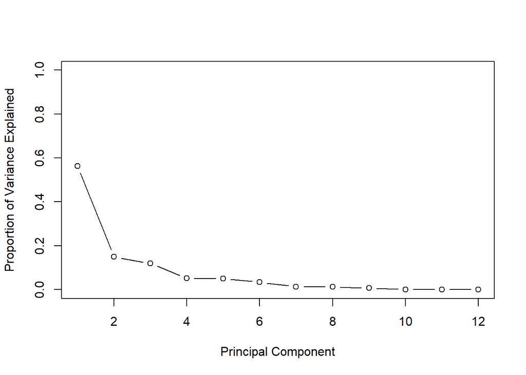

```r
#ploting a scree plot to see the variation of each PC
#getting the variance
pr<- sales_pca$sdev^2
#getting propotion
pve<- pr/sum(pr)
#ploting scree plot
plot(pve, xlab = "Principal Component",
     ylab = "Proportion of Variance Explained",
     ylim = c(0, 1), type = "b")
```

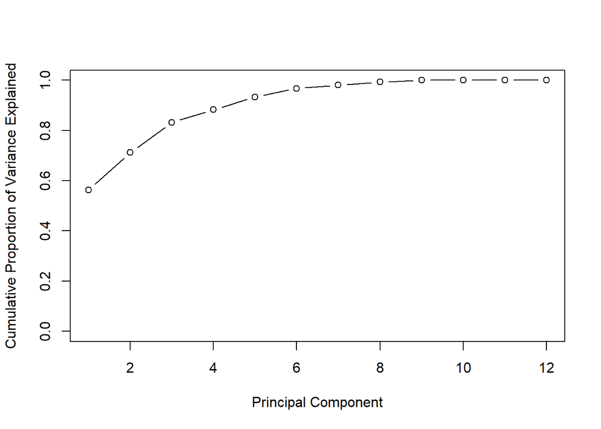

```r
# Plot cumulative proportion of variance explained
plot(cumsum(pve), xlab = "Principal Component",
     ylab = "Cumulative Proportion of Variance Explained",
     ylim = c(0, 1), type = "b")
```

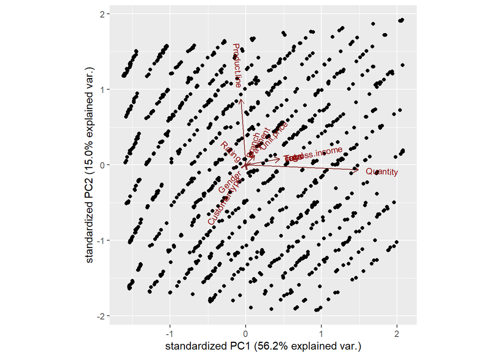

```r
#ploting biplot using the first 2 PCs
ggbiplot(sales_pca)
```

from the biplot we can see that the quantity and the product line has the longest vectors thus they contribute the most variability the quantity contributes more to PC1 and the product line contribute more to PC2 the gross income and the quantity are closely corelated as the angle between the vectors are small

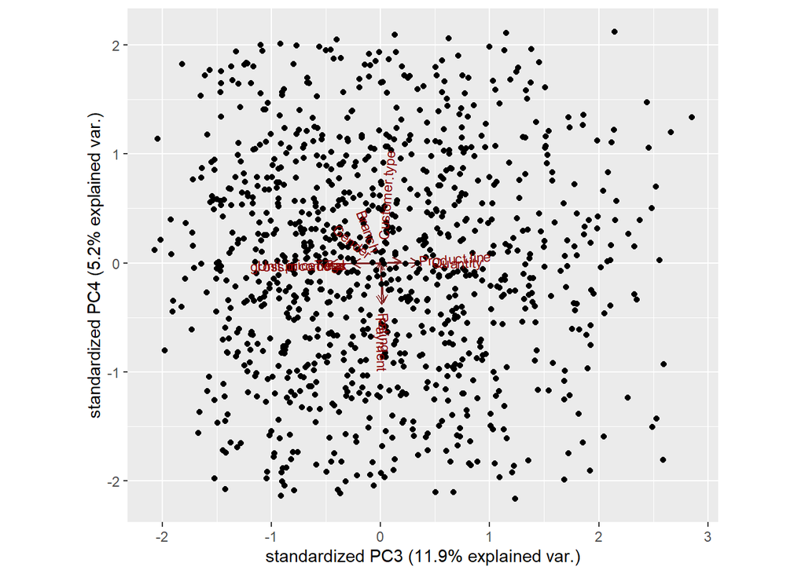

```r
#ploting biplot using the third and fourth  PCs
ggbiplot(sales_pca,choices = c(3,4))
```

the length of the vectors are short since most variability have been accounted by the first two components **feature selection**

```r
# calculate correlation matrix
correlationMatrix <- cor(sales_data)
# summarize the correlation matrix
print(correlationMatrix)
```

```
##                     Branch Customer.type       Gender Product.line     Quantity
## Branch         1.000000000  -0.004899261 -0.012218875   0.01257525  0.002120920
## Customer.type -0.004899261   1.000000000  0.039996160  -0.02510945 -0.016762706
## Gender        -0.012218875   0.039996160  1.000000000  -0.06612647 -0.074258307
## Product.line   0.012575246  -0.025109450 -0.066126475   1.00000000 -0.062514713
## Quantity       0.002120920  -0.016762706 -0.074258307  -0.06251471  1.000000000
## Unit.price     0.013763477  -0.020237875  0.015444630   0.03842765  0.010777564
## Tax            0.012811933  -0.019670283 -0.049450989  -0.01854396  0.705510186
## Payment        0.026725563  -0.069286242 -0.049514182   0.01051098  0.007333388
## cogs           0.012811933  -0.019670283 -0.049450989  -0.01854396  0.705510186
## gross.income   0.012811933  -0.019670283 -0.049450989  -0.01854396  0.705510186
## Rating        -0.049585348   0.018888672  0.004800208   0.02339096 -0.015814905
## Total          0.012811933  -0.019670283 -0.049450989  -0.01854396  0.705510186
##                 Unit.price          Tax      Payment         cogs gross.income
## Branch         0.013763477  0.012811933  0.026725563  0.012811933  0.012811933
## Customer.type -0.020237875 -0.019670283 -0.069286242 -0.019670283 -0.019670283
## Gender         0.015444630 -0.049450989 -0.049514182 -0.049450989 -0.049450989
## Product.line   0.038427649 -0.018543956  0.010510982 -0.018543956 -0.018543956
## Quantity       0.010777564  0.705510186  0.007333388  0.705510186  0.705510186
## Unit.price     1.000000000  0.633962089 -0.019637884  0.633962089  0.633962089
## Tax            0.633962089  1.000000000  0.008823723  1.000000000  1.000000000
## Payment       -0.019637884  0.008823723  1.000000000  0.008823723  0.008823723
## cogs           0.633962089  1.000000000  0.008823723  1.000000000  1.000000000
## gross.income   0.633962089  1.000000000  0.008823723  1.000000000  1.000000000
## Rating        -0.008777507 -0.036441705  0.013001094 -0.036441705 -0.036441705
## Total          0.633962089  1.000000000  0.008823723  1.000000000  1.000000000
##                     Rating        Total
## Branch        -0.049585348  0.012811933
## Customer.type  0.018888672 -0.019670283
## Gender         0.004800208 -0.049450989
## Product.line   0.023390962 -0.018543956
## Quantity      -0.015814905  0.705510186
## Unit.price    -0.008777507  0.633962089
## Tax           -0.036441705  1.000000000
## Payment        0.013001094  0.008823723
## cogs          -0.036441705  1.000000000
## gross.income  -0.036441705  1.000000000
## Rating         1.000000000 -0.036441705
## Total         -0.036441705  1.000000000
```

```r
# find attributes that are highly corrected (ideally >0.75)
highlyCorrelated <- findCorrelation(correlationMatrix, cutoff=0.75)
# print indexes of highly correlated attributes
print(highlyCorrelated)
```

```
## [1]  7  9 10
```

we see that the highly correlated attributes are tax,cogs,gross.income and thus we remove them

```r
#we now remove the highly correlleted variables
sales_data1<- sales_data[-(highlyCorrelated)]
head(sales_data1)
```

```
##   Branch Customer.type Gender Product.line Quantity  Unit.price     Payment
## 1      0             0      0            0        7  0.71780097 -1.19313873
## 2      1             1      0            1        5 -1.52454035  0.04199453
## 3      0             1      1            2        7 -0.35260468  1.27712779
## 4      0             0      1            0        8  0.09616553 -1.19313873
## 5      0             1      1            3        7  1.15638044 -1.19313873
## 6      1             1      1            1        7  1.12165642 -1.19313873
##       Rating       Total
## 1  1.2378240  0.91914693
## 2  1.5287619 -0.98723557
## 3  0.2486355  0.07141032
## 4  0.8305111  0.67544187
## 5 -0.9733034  1.26649176
## 6 -1.6715541  1.23899114
```

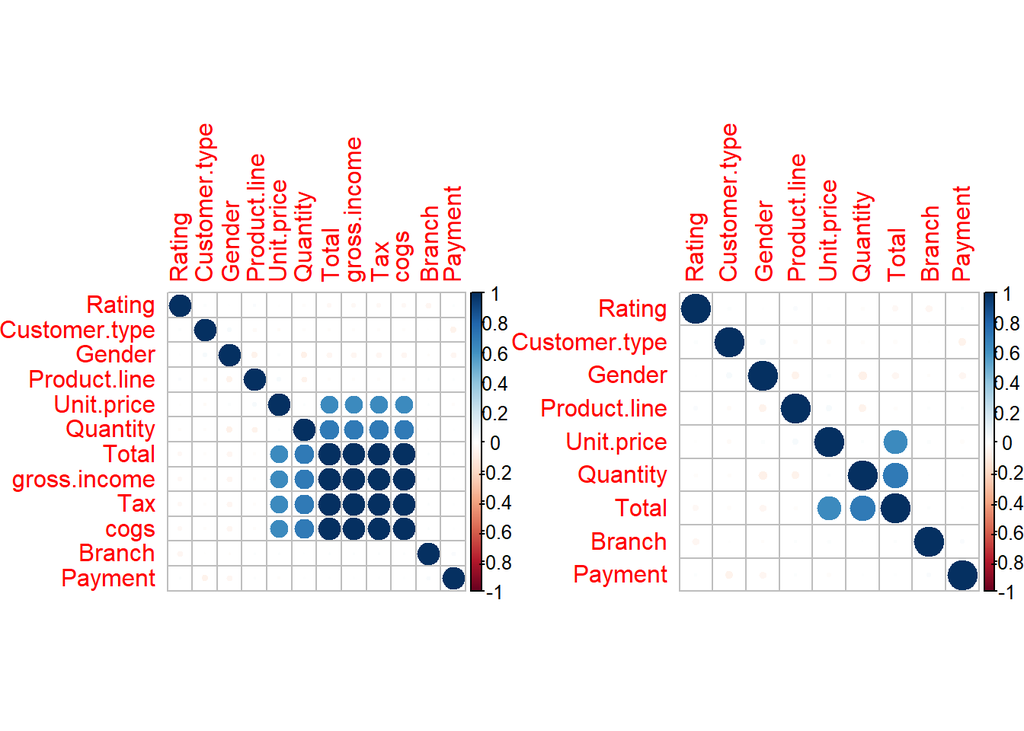

```r
#making graphical presantation before and after removing the highly correlated features
par(mfrow = c(1, 2))
corrplot(correlationMatrix, order = "hclust")
corrplot(cor(sales_data1), order = "hclust")
```